# Data 607 Week 10 Assignment

Sung Lee

4/1/2020

[Assignment on RPubs](https://rpubs.com/logicalschema/data607_week10)  
[Rmd on Github](https://github.com/logicalschema/DATA607/blob/master/week10/SungLee-Week10.Rmd)

## Introduction

**Assignment**

In Text Mining with R, Chapter 2 looks at Sentiment Analysis. In this assignment, you should start by getting the primary example code from chapter 2 working in an R Markdown document. You should provide a citation to this base code. You’re then asked to extend the code in two ways:

- Work with a different corpus of your choosing, and
- Incorporate at least one additional sentiment lexicon (possibly from another R package that you’ve found through research).

As usual, please submit links to both an .Rmd file posted in your GitHub repository and to your code on rpubs.com. You may work as a small team on this assignment.

**Note:** If you initially encounter problems loading AFINN, you will need to accept the license for the lexicon by typing in the console for R Markdown.

## Example from Textbook

The code below is an example from chapter 2 of *Text Mining with R*[^1]

The example uses the `AFINN` lexicon to analyze sentiment for Jane Austen’s *Pride and Prejudice*.

```r
# Based on code from https://www.tidytextmining.com/sentiment.html

library(tidytext)
library(dplyr)
```

```r
library(stringr)
library(janeaustenr)
library(ggplot2)

get_sentiments("afinn")
```

| word | value |
| --- | --- |
| abandon | -2 |
| abandoned | -2 |
| abandons | -2 |
| abducted | -2 |
| abduction | -2 |
| abductions | -2 |
| abhor | -3 |
| abhorred | -3 |
| abhorrent | -3 |
| abhors | -3 |

[output cut: 2467 more lines]

```r
tidy_books <- austen_books() %>%
  group_by(book) %>%
  mutate(linenumber = row_number(),
         chapter = cumsum(str_detect(text, regex("^chapter [\\divxlc]",
                                                 ignore_case = TRUE)))) %>%
  ungroup() %>%
  unnest_tokens(word, text)
```

```r
pride_prejudice <- tidy_books %>%
  filter(book == "Pride & Prejudice")

pride_prejudice
```

| book | linenumber | chapter | word |
| --- | --- | --- | --- |
| Pride & Prejudice | 1 | 0 | pride |
| Pride & Prejudice | 1 | 0 | and |
| Pride & Prejudice | 1 | 0 | prejudice |
| Pride & Prejudice | 3 | 0 | by |
| Pride & Prejudice | 3 | 0 | jane |
| Pride & Prejudice | 3 | 0 | austen |
| Pride & Prejudice | 7 | 1 | chapter |
| Pride & Prejudice | 7 | 1 | 1 |
| Pride & Prejudice | 10 | 1 | it |
| Pride & Prejudice | 10 | 1 | is |

[output cut: 9990 more lines]

```r
afinn <- pride_prejudice %>%
  inner_join(get_sentiments("afinn")) %>%
  group_by(index = linenumber %/% 80) %>%
  summarise(sentiment = sum(value)) %>%
  mutate(method = "AFINN")
```

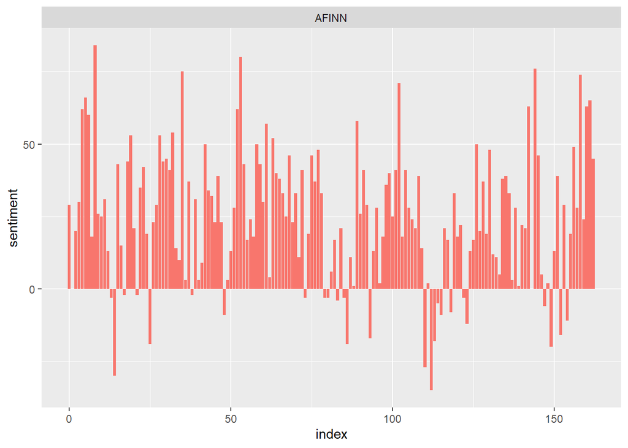

```r
bind_rows(afinn) %>%
  ggplot(aes(index, sentiment, fill = method)) +
  geom_col(show.legend = FALSE) +
  facet_wrap(~method, ncol = 1, scales = "free_y")
```

## Loughran Sentiment Lexicon

I will use the loughran`. I found it on this page: https://www.rdocumentation.org/packages/tidytext/versions/0.2.3/topics/get_sentiments

**Note:** If you initially encounter problems loading loughran, you will need to accept the license for the lexicon by typing in the console for R Markdown.

```r
get_sentiments("loughran")
```

| word | sentiment |
| --- | --- |
| abandon | negative |
| abandoned | negative |
| abandoning | negative |
| abandonment | negative |
| abandonments | negative |
| abandons | negative |
| abdicated | negative |
| abdicates | negative |
| abdicating | negative |
| abdication | negative |

[output cut: 4140 more lines]

## Corpus

I will use the `harrypotter` package[^2]. It contains several of novels from the *Harry Potter* series. I will use *Harry Potter and the Order of the Phoenix*.

```r
library(tidyverse)
library(stringr)

# Code based on https://afit-r.github.io/sentiment_analysis
devtools::install_github("bradleyboehmke/harrypotter")
library(harrypotter)
```

This is a sample of the corpus:

```r
order_of_the_phoenix[1:1]
```

```
## [1] "Dudley Demented    The hottest day of the summer so far was drawing to a close and a drowsy silence lay over the large, square houses of Privet Drive. Cars that were usually gleaming stood dusty in their drives and lawns that were once emerald green lay parched and yellowing - 'for the use o…
```

## Import

```r
# Code based on https://afit-r.github.io/sentiment_analysis
titles <- c("Order of the Phoenix")
books <- list(order_of_the_phoenix)
series <- tibble()

for(i in seq_along(titles)) {

  temp <- tibble(chapter = seq_along(books[[i]]),
                  text = books[[i]]) %>%
    unnest_tokens(word, text) %>%
    ##Here we tokenize each chapter into words
    mutate(book = titles[i]) %>%
    select(book, everything())

  series <- rbind(series, temp)
}
# set factor to keep books in order of publication
series$book <- factor(series$book, levels = rev(titles))

# This is what the tokenizing looks like
series
```

| book | chapter | word |
| --- | --- | --- |
| Order of the Phoenix | 1 | dudley |
| Order of the Phoenix | 1 | demented |
| Order of the Phoenix | 1 | the |
| Order of the Phoenix | 1 | hottest |
| Order of the Phoenix | 1 | day |
| Order of the Phoenix | 1 | of |
| Order of the Phoenix | 1 | the |
| Order of the Phoenix | 1 | summer |
| Order of the Phoenix | 1 | so |
| Order of the Phoenix | 1 | far |

[output cut: 9990 more lines]

## Analysis

Here is sentiment analysis on the book using the `AFINN` lexicon.

```r
# Using the AFINN lexicon for sentiment analysis on Harry Potter
afinn <- series %>%
        group_by(book) %>%
        mutate(word_count = 1:n(),
               index = word_count %/% 500 + 1) %>%
        inner_join(get_sentiments("afinn")) %>%
        group_by(book, index) %>%
        summarise(sentiment = sum(value)) %>%
        mutate(method = "AFINN")
#A view of the AFINN analysis
afinn
```

| book | index | sentiment | method |
| --- | --- | --- | --- |
| Order of the Phoenix | 1 | 0 | AFINN |
| Order of the Phoenix | 2 | 9 | AFINN |
| Order of the Phoenix | 3 | -5 | AFINN |
| Order of the Phoenix | 4 | 3 | AFINN |
| Order of the Phoenix | 5 | -10 | AFINN |
| Order of the Phoenix | 6 | -24 | AFINN |
| Order of the Phoenix | 7 | -15 | AFINN |
| Order of the Phoenix | 8 | 13 | AFINN |
| Order of the Phoenix | 9 | -21 | AFINN |
| Order of the Phoenix | 10 | -23 | AFINN |

[output cut: 508 more lines]

Now, let’s take a look at the Loughran lexicon for sentiment analysis.

```r
# Using the Loughran lexicon for sentiment analysis on Harry Potter
loughran <- series %>%
  right_join(get_sentiments("loughran")) %>%
  filter(!is.na(sentiment)) %>%
  count(sentiment, sort = TRUE)
#A view of the Loughran analysis
loughran
```

| sentiment | n |
| --- | --- |
| negative | 5350 |
| uncertainty | 2123 |
| positive | 1793 |
| litigious | 1151 |
| constraining | 305 |
| superfluous | 58 |

```r
#Prepares loughran for plotting
loughran <- bind_rows(series %>%
                  group_by(book) %>%
                  mutate(word_count = 1:n(),
                         index = word_count %/% 500 + 1) %>%
                  inner_join(get_sentiments("loughran") %>%
                                     filter(sentiment %in% c("positive", "negative"))) %>%
                  mutate(method = "Loughran")) %>%
        count(book, method, index = index , sentiment) %>%
        ungroup() %>%
        spread(sentiment, n, fill = 0) %>%
        mutate(sentiment = positive - negative) %>%
        select(book, index, method, sentiment)
```

Here is a comparison of the the Loughlan and Afinn analyses.

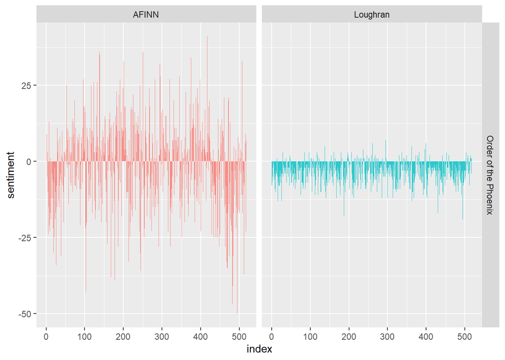

```r
bind_rows(afinn,
          loughran) %>%
        ungroup() %>%
        mutate(book = factor(book, levels = titles)) %>%
  ggplot(aes(index, sentiment, fill = method)) +
  geom_bar(alpha = 0.8, stat = "identity", show.legend = FALSE) +
  facet_grid(book ~ method)
```

[^1]: https://www.tidytextmining.com/sentiment.html
[^2]: https://cran.r-project.org/web/packages/harrypotter/index.html